# Different Numbering Systems

Inspired by the [seximal system](https://www.seximal.net/)

Is there a better number system available than base 10? Ignoring more esoteric systems like [signed-digit representations](https://en.wikipedia.org/wiki/Signed-digit_representation) and sticking to ordinary positional systems, what's the best base available? This post explores this problem in Python.

```python
from collections import defaultdict
from IPython.display import Latex, Markdown
from tabulate import tabulate
from sympy import factorint
```

First, we need a function to represent integers in different bases. The algorith we use just repeatedly divides the given number by the base and stores the remainder. The result is stored in a dictionary.

```python
def convert_integer(num, syms):
    """Given an integer and a list of symbols of a base to represent it in,
    returns a dictionary containing the string representation of the number in that base"""
    res = []
    base = len(syms)
    todo = num
    while todo:
        remainder = todo % base
        todo = todo // base
        res.append(syms[remainder])
    if not res:
        return dict(integer_part=[syms[0]])
    return dict(integer_part=list(reversed(res)))
```

Let's use our function to write the number 255 in base 2.

```python
convert_integer(255, "01")
```

```
{'integer_part': ['1', '1', '1', '1', '1', '1', '1', '1']}
```

The result is returned as a dictionary. This will be useful later.

We also need a function to express fractions in different bases. This has to implement a long division algorithm, which is more or less straightforward. It also has to identify repeating sequences of digits, which it does by storing the numerator in each long division operation in a set; if the same numerator shows up twice (and we're on the right side of the decimal point) then we have hit a repeat.

```python
def convert_fraction(num, denom, symbols):
    """Given a numerator, a denominator, and a list of symbols for a base to
    represent the result in, returns a dictionary containing the string representation
    of the number expressed in the desired base"""
    todo = num
    base = len(symbols)
    result = []
    digits = 0
    previous_operands = {}
    has_decimal = False
    while todo not in previous_operands or not has_decimal:
        # If we haven't placed a decimal point yet, we can't quit early when we
        # hit a repeating sequence
        if has_decimal:
            previous_operands[todo] = digits
        intermediate = convert_integer(todo // denom, symbols)["integer_part"]
        result += list(intermediate)
        digits += len(intermediate)
        todo = todo % denom
        if not has_decimal and todo < denom:
            result.append(".")
            digits += 1
            has_decimal = True
        todo *= base
    repeat_start = previous_operands[todo]
    repeating_part = result[repeat_start:]
    if repeating_part == [symbols[0]]:
        repeating_part = []
    fixed_part = result[result.index(".") + 1 : repeat_start]
    integer_part = result[: result.index(".")]
    return dict(
        integer_part=integer_part, fixed_part=fixed_part, repeating_part=repeating_part
    )
```

Let's check our long division algorithm by comuting $\frac{1}{12}$ in base 10.

```python
convert_fraction(1, 12, "0123456789")
```

```
{'integer_part': ['0'], 'fixed_part': ['0', '8'], 'repeating_part': ['3']}
```

Now we just need to define a few utility functions to pretty-print our results and generate lists of symbols easily.

```python
def repr_value(d):
    """Represents a dictionary containing the parts of a rational number in
    a particular base as a string"""
    d2 = defaultdict(list)
    d2.update(d)
    int_part = "".join(d2["integer_part"])
    fix_part = "".join(d2["fixed_part"])
    rep_part = "".join(d2["repeating_part"])
    if rep_part:
        return f"${int_part}.{fix_part}\\overline{{{rep_part}}}$"
    else:
        return f"${int_part}.{fix_part}$"
```

```python
def get_syms(num_syms):
    """Gets a list of symbols to use as digits in a number system of a given
    base"""
    if num_syms > 64:
        raise NotImplementedError
    syms = []
    for i in range(num_syms):
        if i < 10:
            offset = ord("0")
        elif i < 36:
            offset = ord("A") - 10
        else:
            offset = ord("a") - 36
        syms.append(chr(i + offset))
    return syms
```

Let's try computing $\frac{1}{12}$ in a few different bases:

```python
for base in range(2, 13):
    display(
        Markdown(f"Base ${base}$: " + repr_value(convert_fraction(1, 12, get_syms(base)))))
```

Base $2$: $0.00\overline{01}$

Base $3$: $0.0\overline{02}$

Base $4$: $0.0\overline{1}$

Base $5$: $0.\overline{02}$

Base $6$: $0.03$

Base $7$: $0.\overline{04}$

Base $8$: $0.0\overline{52}$

Base $9$: $0.0\overline{6}$

Base $10$: $0.08\overline{3}$

Base $11$: $0.\overline{0A}$

Base $12$: $0.1$

Unsurprisingly, the best representation for $\frac{1}{12}$ is in base 12, and the second best is in base 6. I'm a bit surprised to see how bad $\frac{1}{12}$ looks in base 8: two repeating digits and both are non-zero.

```python
def compute_badness(d, denom, base, repeat_penalty=2):
    """Computes a "badness score" for the numerical representation of a ratio
    in a given base"""
    score = 0
    score += len(d["fixed_part"])
    score += repeat_penalty * len(d["repeating_part"])
    # Denominators with more factors are more important to represent.
    # Larger denominators are less important than smaller denominators
    denom_penalty = sum(factorint(denom).values())
    # Weight denominators with more factors are more important
    denom_penalty **= 2
    score *= denom_penalty
    score *= base ** 0.25  # penalize bigger bases
    score /= denom  # Bigger denominators are less important to represent
    return score
```

```python
data = []
header = []
badnesses = {}
header.append("Fraction")
for denom in range(2, 120):
    row = []
    row.append(fr"$\frac{{1}}{{{denom}}}$")
    for base in range(2, 61):
        if not data:
            header.append(f"Base {base}")
        num_dict = convert_fraction(1, denom, get_syms(base))
        badness = compute_badness(num_dict, denom, base)
        row.append(repr_value(num_dict))
        total_badness = badnesses.get(base, 0)
        total_badness += badness
        badnesses[base] = total_badness
    data.append(row)
```

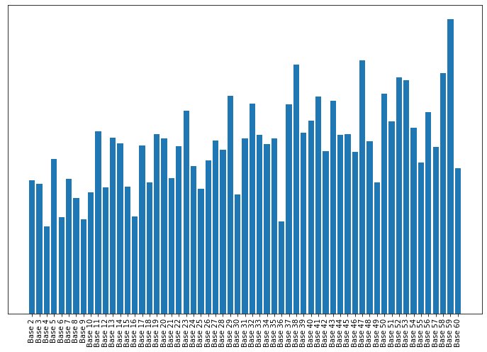

```python
import matplotlib.pyplot as plt

plt.figure(figsize=(12, 8))
plt.bar(
    list(badnesses.keys()), list(badnesses.values()),
)
plt.xticks(
    list(badnesses.keys()),
    labels=[f"Base {x}" for x in badnesses.keys()],
    rotation="vertical",
)
plt.yticks(ticks=[])
plt.ylabel("")
```